# Body performance

#### Visualization of Cluters:

In this section, we will perform k-means clustering and visualize its result using three different k’s that have been chosen based on methods that we tasted earlier k=2(highest average sillhouette width), k=3(from Kmeansruns), k=4(total within-cluster sum of square method). then we will compute WSS and Bcubed preceision and recall and average silhouette for each cluster as methods of evaluating clustering results.

### 1- 2-Means Cluster:

Calculate K-means for k=2:

```r
#set a seed for random number generation to make the results reproducible
set.seed(8953)

kmeans.result <- kmeans(dataset, 2)

# print the clusterng result
kmeans.result
```

```
K-means clustering with 2 clusters of sizes 4620, 8431

Cluster means:
       age    gender  height_cm   weight_kg body.fat_.  diastolic   systolic
1 52.02662 0.5943723 -0.3598162 -0.14102240  0.2870214  0.2036609  0.2286763
2 27.49662 0.6633851  0.1971712  0.07727713 -0.1572813 -0.1116016 -0.1253095
   gripForce sit.and.bend.forward_cm sit.ups.counts broad.jump_cm
1 -0.2448670             -0.09090508     -0.6639297    -0.5212396
2  0.1341817              0.04981396      0.3638187     0.2856277

Clustering vector:
   1    2    3    4    5    6    7    8    9   10   11   13   14   15   16   17
   2    2    2    2    2    2    1    2    1    2    1    2    2    2    1    2
  18   19   20   21   22   23   24   25   26   27   28   29   30   31   32   33
   2    2    2    2    1    2    1    2    1    1    1    2    1    2    2    2
```

[output cut: 132 more lines]

#### visualize 2 clusters

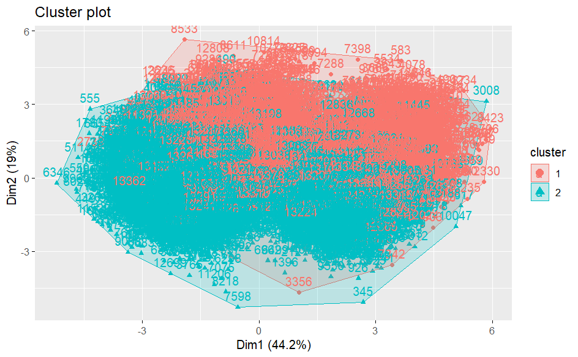

```r
library(factoextra)
fviz_cluster(kmeans.result, data = dataset)
```

#### average silhouette for 2 clusters

```r
library(cluster)
avg_sil <- silhouette(kmeans.result$cluster,dist(dataset))

fviz_silhouette(avg_sil)
```

|  | cluster | size | ave.sil.width |
| --- | --- | --- | --- |
| 1 | 1 | 4620 | 0.56 |
| 2 | 2 | 8431 | 0.67 |

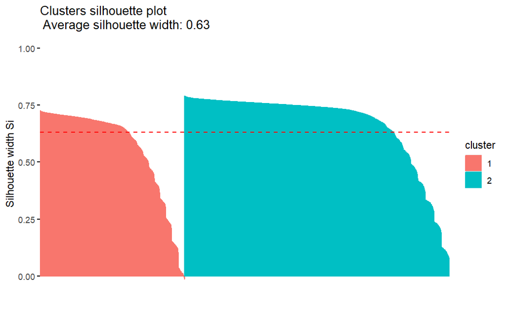

#### Within cluster sum of squares by cluster:

```r
kmeans.result$tot.withinss
```

```
[1] 591064.6
```

#### BCubed precision and recall for k=2:

```r
cluster_assignments <- c(kmeans.result$cluster)
ground_truth_labels <- c(dataWithclass$class)

data <- data.frame(cluster = cluster_assignments, label = ground_truth_labels)

# Function to calculate BCubed precision and recall
calculate_bcubed_metrics <- function(data) {
  n <- nrow(data)
  precision_sum <- 0
  recall_sum <- 0

  for (i in 1:n) {
    cluster <- data$cluster[i]
    label <- data$label[i]

# Count the number of items from the same category within the same cluster
same_category_same_cluster <- sum(data$label[data$cluster == cluster] == label)

# Count the total number of items in the same cluster
total_same_cluster <- sum(data$cluster == cluster)

# Count the total number of items with the same category
total_same_category <- sum(data$label == label)

# Calculate precision and recall for the current item and add them to the sums
precision_sum <- precision_sum + same_category_same_cluster /total_same_cluster
recall_sum <- recall_sum + same_category_same_cluster / total_same_category
  }

  # Calculate average precision and recall
  precision <- precision_sum / n
  recall <- recall_sum / n

  return(list(precision = precision, recall = recall))
}

# Calculate BCubed precision and recall
metrics <- calculate_bcubed_metrics(data)

# Extract precision and recall from the metrics
precision <- metrics$precision
recall <- metrics$recall

# Print the results
cat("BCubed Precision:", precision, "\n")
```

```
BCubed Precision: 0.2516112
```

```r
cat("BCubed Recall:", recall, "\n")
```

```
BCubed Recall: 0.5454527
```

-The silhouette width and WCSS suggest that k=2 provides a reasonable clustering solution, with well-defined and compact clusters.

-The BCubed Precision and Recall values indicate the effectiveness of the clustering with respect to the ground truth labels. A Precision of 0.25 suggests that about 25% of instances within the same cluster have the same ground truth label, while a Recall of 0.55 indicates that about 55% of instances with the same ground truth label are in the same cluster.

### 2- 3-Means Cluster:

```r
#set a seed for random number generation  to make the results reproducible
set.seed(8953)
kmeans.result <- kmeans(dataset, 3)

# print the clusterng result
kmeans.result
```

```
K-means clustering with 3 clusters of sizes 2927, 6760, 3364

Cluster means:
       age    gender   height_cm   weight_kg  body.fat_.  diastolic    systolic
1 56.74172 0.5661086 -0.54512189 -0.26796473  0.39209269  0.1915948  0.32829869
2 25.37929 0.6513314  0.19154009  0.03656116 -0.18018562 -0.1605107 -0.15460285
3 39.99405 0.6774673  0.08940569  0.15968469  0.02092732  0.1558425  0.02502526
   gripForce sit.and.bend.forward_cm sit.ups.counts broad.jump_cm
1 -0.3892011             -0.05639624    -0.89031821   -0.76464906
2  0.1019425              0.06682778     0.42180554    0.29591228
3  0.1337872             -0.08522117    -0.07296196    0.07067799

Clustering vector:
   1    2    3    4    5    6    7    8    9   10   11   13   14   15   16   17
   2    2    2    2    2    3    3    3    1    2    3    2    2    2    3    2
```

[output cut: 134 more lines]

#### visualize 3 clusters

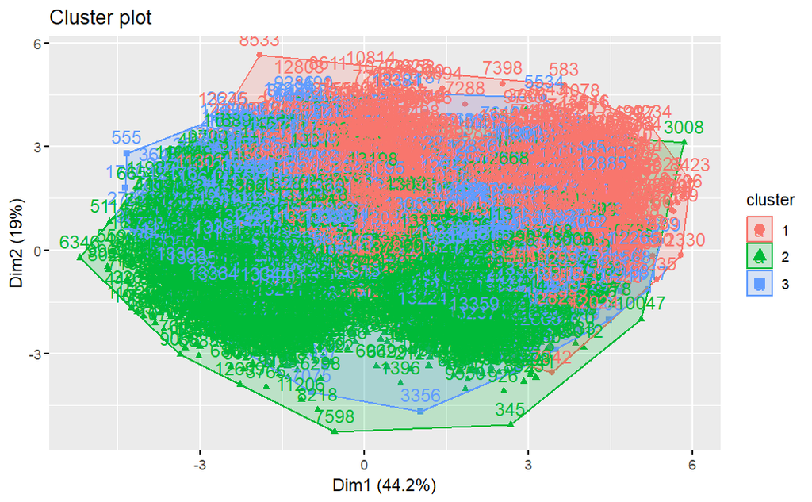

```r
# visualize clustering (2 clusters)
#install.packages("factoextra")
library(factoextra)
fviz_cluster(kmeans.result, data = dataset)
```

#### average silhouette for 3 clusters

```r
library(cluster)
avg_sil <- silhouette(kmeans.result$cluster,dist(dataset))

fviz_silhouette(avg_sil)
```

|  | cluster | size | ave.sil.width |
| --- | --- | --- | --- |
| 1 | 1 | 2927 | 0.58 |
| 2 | 2 | 6760 | 0.60 |
| 3 | 3 | 3364 | 0.41 |

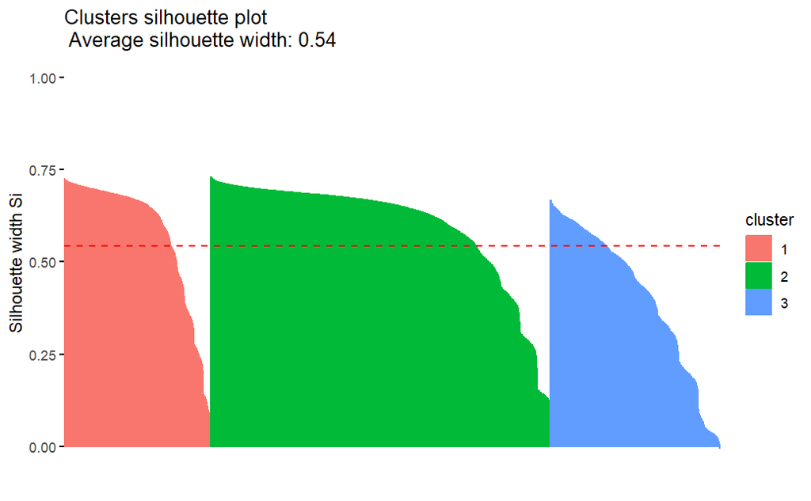

#### Within cluster sum of squares by cluster:

```r
kmeans.result$tot.withinss
```

```
[1] 310351.6
```

#### BCubed precision and recall for k=3:

```r
cluster_assignments <- c(kmeans.result$cluster)
ground_truth_labels <- c(dataWithclass$class)

data <- data.frame(cluster = cluster_assignments, label = ground_truth_labels)

# Function to calculate BCubed precision and recall
calculate_bcubed_metrics <- function(data) {
  n <- nrow(data)
  precision_sum <- 0
  recall_sum <- 0

  for (i in 1:n) {
    cluster <- data$cluster[i]
    label <- data$label[i]

# Count the number of items from the same category within the same cluster
same_category_same_cluster <- sum(data$label[data$cluster == cluster] == label)

# Count the total number of items in the same cluster
total_same_cluster <- sum(data$cluster == cluster)

# Count the total number of items with the same category
total_same_category <- sum(data$label == label)

# Calculate precision and recall for the current item and add them to the sums
precision_sum <- precision_sum + same_category_same_cluster /total_same_cluster
recall_sum <- recall_sum + same_category_same_cluster / total_same_category
  }

  # Calculate average precision and recall
  precision <- precision_sum / n
  recall <- recall_sum / n

  return(list(precision = precision, recall = recall))
}

# Calculate BCubed precision and recall
metrics <- calculate_bcubed_metrics(data)

# Extract precision and recall from the metrics
precision <- metrics$precision
recall <- metrics$recall

# Print the results
cat("BCubed Precision:", precision, "\n")
```

```
BCubed Precision: 0.2516393
```

```r
cat("BCubed Recall:", recall, "\n")
```

```
BCubed Recall: 0.387276
```

-The average silhouette width of 0.54 suggests that there is a moderate separation between clusters, but it might not be as distinct as in the case of k=2.

-The lower WCSS (310351.6) compared to k=2 implies that the clusters are more compact, indicating that data points within each cluster are closer to each other. -These values indicate that about 25% of instances within the same cluster have the same ground truth label (Precision), and about 39% of instances with the same ground truth label are in the same cluster (Recall).

### 3- 4-Means Cluster :

```r
#set a seed for random number generation  to make the results reproducible
set.seed(8953)
kmeans.result <- kmeans(dataset, 4)

# print the clusterng result
kmeans.result
```

```
K-means clustering with 4 clusters of sizes 2584, 3111, 2508, 4848

Cluster means:
       age    gender   height_cm   weight_kg body.fat_.   diastolic     systolic
1 57.69776 0.5727554 -0.56792264 -0.28029622  0.4043106  0.18130122  0.354628131
2 31.78367 0.7389907  0.29501288  0.27247972 -0.1655328  0.06079118  0.005814156
3 43.64035 0.6255981 -0.05428425  0.05189276  0.1134649  0.19309336  0.037745030
4 23.67306 0.6169554  0.14147523 -0.05229910 -0.1679736 -0.23553669 -0.212275467
    gripForce sit.and.bend.forward_cm sit.ups.counts broad.jump_cm
1 -0.39897144             -0.06091930     -0.9270547    -0.7983590
2  0.35619983              0.01276129      0.3556528     0.3604086
3 -0.01475634             -0.11340498     -0.2823826    -0.1201610
4 -0.00828931              0.08294859      0.4119820     0.2564135

Clustering vector:
```

[output cut: 136 more lines]

```r
# visualize clustering (2 clusters)
#install.packages("factoextra")
library(factoextra)
fviz_cluster(kmeans.result, data = dataset)
```

[output not shown]

#### average silhouette for 4 clusters:

|  | cluster | size | ave.sil.width |
| --- | --- | --- | --- |
| 1 | 1 | 2584 | 0.55 |
| 2 | 2 | 3111 | 0.30 |
| 3 | 3 | 2508 | 0.37 |
| 4 | 4 | 4848 | 0.46 |

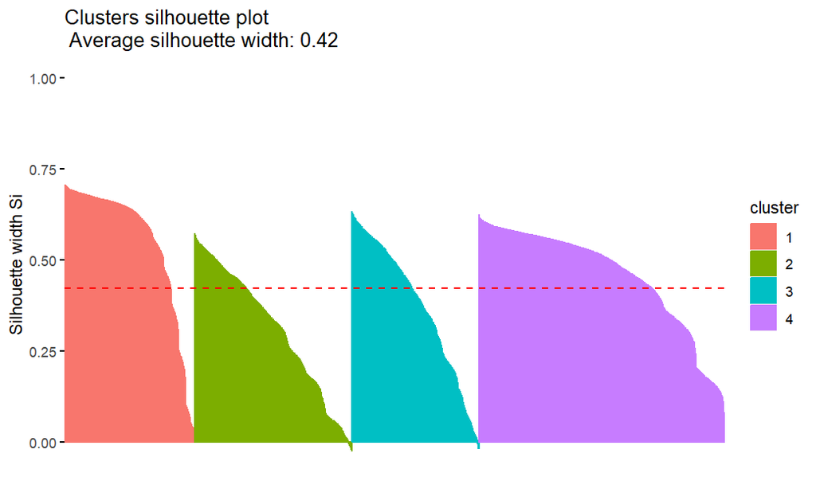

```r
library(cluster)
avg_sil <- silhouette(kmeans.result$cluster,dist(dataset))

fviz_silhouette(avg_sil)
```

#### Within cluster sum of squares by cluster:

```r
kmeans.result$tot.withinss
```

```
[1] 230049.1
```

#### BCubed precision and recall for k=4:

```r
cluster_assignments <- c(kmeans.result$cluster)
ground_truth_labels <- c(dataWithclass$class)

data <- data.frame(cluster = cluster_assignments, label = ground_truth_labels)

# Function to calculate BCubed precision and recall
calculate_bcubed_metrics <- function(data) {
  n <- nrow(data)
  precision_sum <- 0
  recall_sum <- 0

  for (i in 1:n) {
    cluster <- data$cluster[i]
    label <- data$label[i]

# Count the number of items from the same category within the same cluster
same_category_same_cluster <- sum(data$label[data$cluster == cluster] == label)

# Count the total number of items in the same cluster
total_same_cluster <- sum(data$cluster == cluster)

# Count the total number of items with the same category
total_same_category <- sum(data$label == label)

# Calculate precision and recall for the current item and add them to the sums
precision_sum <- precision_sum + same_category_same_cluster /total_same_cluster
recall_sum <- recall_sum + same_category_same_cluster / total_same_category
  }

  # Calculate average precision and recall
  precision <- precision_sum / n
  recall <- recall_sum / n

  return(list(precision = precision, recall = recall))
}

# Calculate BCubed precision and recall
metrics <- calculate_bcubed_metrics(data)

# Extract precision and recall from the metrics
precision <- metrics$precision
recall <- metrics$recall

# Print the results
cat("BCubed Precision:", precision, "\n")
```

```
BCubed Precision: 0.2522583
```

```r
cat("BCubed Recall:", recall, "\n")
```

```
BCubed Recall: 0.2729353
```

-The average silhouette width of 0.42 suggests a moderate level of separation between clusters, indicating that the clusters are distinguishable, but there may be some overlap. -The lower WCSS indicates that the clusters are relatively compact, with instances within each cluster being closer to each other.

-The BCubed metrics : A Precision of 0.25 means that about 25% of instances within the same cluster have the same ground truth label. A Recall of 0.27 means that about 27% of instances with the same ground truth label are in the same cluster.

### Comparison Criteria:

[output not shown]

Upon comparing the results of the clustering task using the k-means algorithm reveal that the most effective cluster configuration is achieved when k=2. This is supported by the higher average silhouette width for cluster 2 (0.67) compared to the other clusters in different configurations. It suggests that instances within cluster 2 are closely grouped and well-separated from instances in other clusters, indicating a higher level of cohesion and separation. Furthermore, the overall average silhouette width for k=2 (0.63) surpasses the average values for k=3 (0.54) and k=4 (0.42), indicating better overall clustering performance.